# GEOG771_Assignment_1

Yuehan Luo

2025-03-13

## Assignemnt 1

```r
library(ggplot2)
library(dplyr)
library(readr)
library(sf)
library(tmap)
library(RColorBrewer)
library(classInt)
```

```r
Deprivation_Scotland_2011DZ_complete <- read_csv("~/Downloads/lab 1_ 2025/data/Deprivation_Scotland_2011DZ_complete.csv", show_col_types = FALSE)
```

Create an Rmarkdown document with a front page in which you answer questions and respond to the set up tasks from Part 1 and Part 2. Make sure that the code and the results are all plotted and formatted appropriately.

Data for Part 1 and Part of this assignment will be available to download from canvas. The datasets for Part 1 come from the same folder as the data for the tutorials from Week 1.

### Part 1:

1. Make 3 histograms for data and variables of your choice. Make sure the graphs have titles, are of different colours and have the axis labeled. For the same variables chosen to look at the distributions provide some descriptive statistics. Put the code, results and the exported graphs into an Rmarkdown document.

```r
Deprivation_Scotland_2011DZ_complete <- as.data.frame(Deprivation_Scotland_2011DZ_complete)

summary(Deprivation_Scotland_2011DZ_complete$no_qual_M_25_64)
```

```
##    Min. 1st Qu.  Median    Mean 3rd Qu.    Max.
##    0.00   28.00   43.00   46.34   61.00  372.00
```

```r
summary(Deprivation_Scotland_2011DZ_complete$no_qual_F_25_64)
```

```
##    Min. 1st Qu.  Median    Mean 3rd Qu.    Max.
##    1.00   25.00   40.00   44.74   59.00  207.00
```

```r
summary(Deprivation_Scotland_2011DZ_complete$no_qual_T_25_64)
```

```
##    Min. 1st Qu.  Median    Mean 3rd Qu.    Max.
##    1.00   53.00   84.00   91.08  121.00  478.00
```

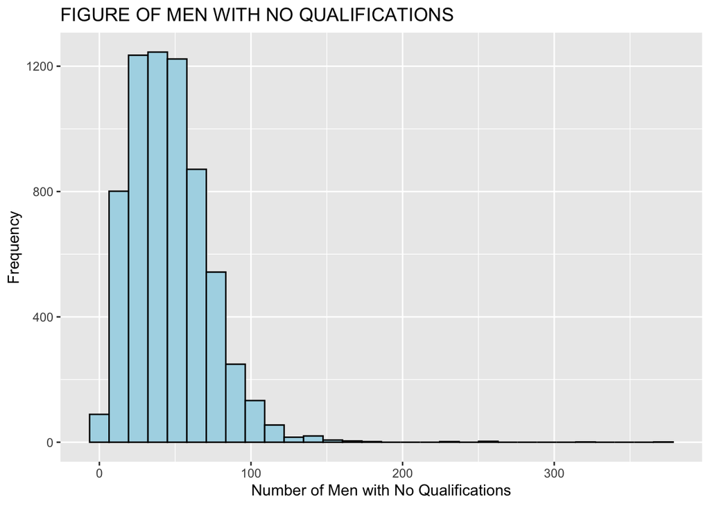

```r
ggplot(Deprivation_Scotland_2011DZ_complete, aes(x = no_qual_M_25_64)) +
  geom_histogram(fill = "lightblue", color = "black", bins = 30) +
  labs(title = "FIGURE OF MEN WITH NO QUALIFICATIONS",
       x = "Number of Men with No Qualifications",
       y = "Frequency")
```

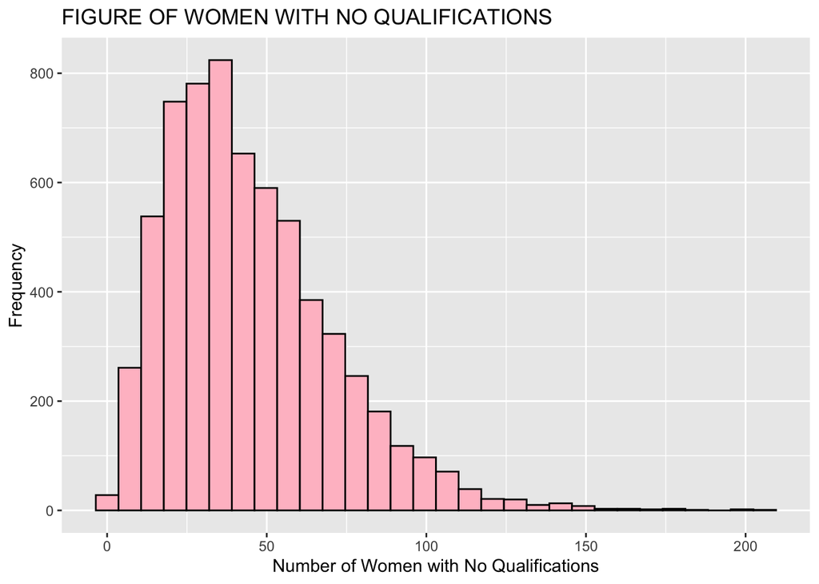

```r
ggplot(Deprivation_Scotland_2011DZ_complete, aes(x = no_qual_F_25_64)) +
  geom_histogram(fill = "pink", color = "black", bins = 30) +
  labs(title = "FIGURE OF WOMEN WITH NO QUALIFICATIONS",
       x = "Number of Women with No Qualifications",
       y = "Frequency")
```

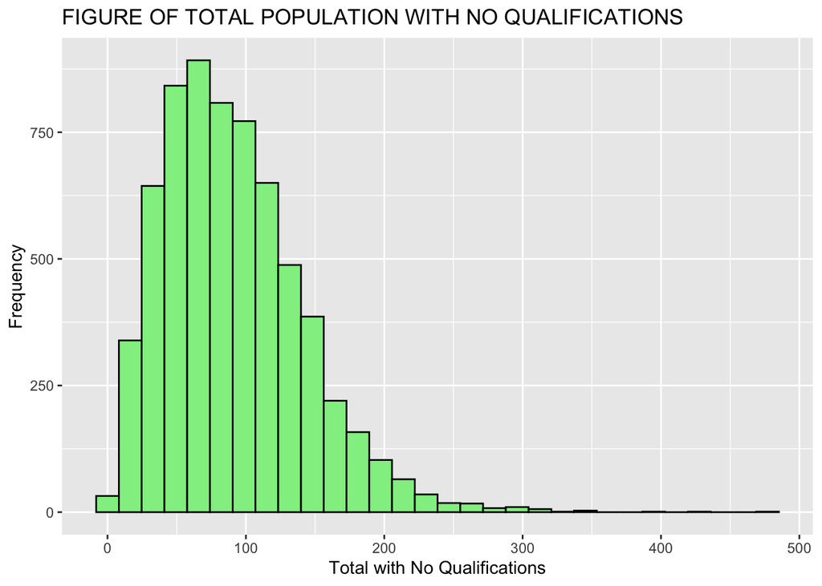

```r
ggplot(Deprivation_Scotland_2011DZ_complete, aes(x = no_qual_T_25_64)) +
  geom_histogram(fill = "lightgreen", color = "black", bins = 30) +
  labs(title = "FIGURE OF TOTAL POPULATION WITH NO QUALIFICATIONS",
       x = "Total with No Qualifications",
       y = "Frequency")
```

2. Read in the csv or the RData version of the dataset Deprivation_Scotland_2011DZ_complete. How many observations and variables are in the dataset, what variables are included in the dataset and how are they coded (types of variables)? Incorporate the code and the responses in your rmarkdown.

```r
dim(Deprivation_Scotland_2011DZ_complete)
```

```
## [1] 6500   92
```

```r
str(Deprivation_Scotland_2011DZ_complete)
```

```
## 'data.frame':    6500 obs. of  92 variables:
##  $ Datazone             : chr  "S01000001" "S01000002" "S01000003" "S01000004" ...
##  $ Health.Board         : chr  "Grampian" "Grampian" "Grampian" "Grampian" ...
##  $ Council.Area         : chr  "Aberdeen City" "Aberdeen City" "Aberdeen City" "Aberdeen City" ...
##  $ Pop.total            : num  872 678 788 612 643 644 751 580 681 514 ...
##  $ Pop.hh               : num  852 678 788 612 643 577 749 580 681 514 ...
##  $ Pop.comm             : num  20 0 0 0 0 67 2 0 0 0 ...
##  $ Quintile             : num  4 5 5 5 5 4 5 4 4 5 ...
##  $ Decile               : num  7 10 10 9 10 8 9 7 8 9 ...
##  $ DEPCAT               : num  3 2 1 2 2 3 2 3 3 2 ...
##  $ Most.dep.15          : num  0 0 0 0 0 0 0 0 0 0 ...
##  $ Least.dep.15         : num  0 1 1 1 1 0 0 0 0 0 ...
##  $ Pop.weight           : num  0.000165 0.000128 0.000149 0.000116 0.000121 ...
##  $ pcnt.overcrowd       : num  2.582 0.737 0.635 1.797 0.778 ...
##  $ pcnt.male.Unemp      : num  3.25 3.52 1.64 2.93 2.15 ...
```

[output cut: 78 more lines]

3. In Deprivation_Scotland_2011DZ_complete the variables no_qual_M_25_64, no_qual_F_25_64 and no_qual_T_25_64 give the number of men, women and total population aged 25-64 with no educational qualifications. Calculate the percent of men, women and total population in that age range with no qualifications. Use the variables all_M_25_64, all_F_25_64 and all_T_25_64 as denominators. How many datazones (spatial administrative unit in Scotland) have over 20% of people aged 25-64 with no qualifications?

```r
Deprivation_Scotland_2011DZ_complete$percentage_M <- (Deprivation_Scotland_2011DZ_complete$no_qual_M_25_64 / Deprivation_Scotland_2011DZ_complete$all_M_25_64) * 100
Deprivation_Scotland_2011DZ_complete$percentage_F <- (Deprivation_Scotland_2011DZ_complete$no_qual_F_25_64 / Deprivation_Scotland_2011DZ_complete$all_F_25_64) * 100
Deprivation_Scotland_2011DZ_complete$percentage_T <- (Deprivation_Scotland_2011DZ_complete$no_qual_T_25_64 / Deprivation_Scotland_2011DZ_complete$all_T_25_64) * 100
print(paste("Percentage of males without qualifications: ", mean(Deprivation_Scotland_2011DZ_complete$percentage_M, na.rm = TRUE), "%"))
```

```
## [1] "Percentage of males without qualifications:  22.4066220730086 %"
```

```r
print(paste("Percentage of females without qualifications: ", mean(Deprivation_Scotland_2011DZ_complete$percentage_F, na.rm = TRUE), "%"))
```

```
## [1] "Percentage of females without qualifications:  20.4968524795571 %"
```

```r
print(paste("Percentage of total population without qualifications: ", mean(Deprivation_Scotland_2011DZ_complete$percentage_T, na.rm = TRUE), "%"))
```

```
## [1] "Percentage of total population without qualifications:  21.4393386662325 %"
```

```r
over_20 <- sum(Deprivation_Scotland_2011DZ_complete$percentage_T > 20, na.rm = TRUE)
print(paste("Number of areas with more than 20% of total population without qualifications: ", over_20))
```

```
## [1] "Number of areas with more than 20% of total population without qualifications:  3242"
```

4. Summarize the variable UR8FOLD. What type is this variable? Create an ordered factor variable of the 8-fold urban-rural classification. The description of the categories is in the file SGUR2011_2012_UR8FOLD_CodeDesc.txt. Try to use short but descriptive variable labels. To learn more about UR8FOLD (2016 Urban Rural Classification. Classification identifying urban and rural areas based on settlement size and drive times) go to https://www.gov.scot/publications/scottish-government-urban-rural-classification-2016/pages/6/ .

```r
str(Deprivation_Scotland_2011DZ_complete$UR8FOLD)
```

```
##  num [1:6500] 3 1 1 1 3 3 3 3 1 1 ...
```

```r
Deprivation_Scotland_2011DZ_complete$UR8FOLD <- factor(Deprivation_Scotland_2011DZ_complete$UR8FOLD, levels = c(1,2,3,4,5,6,7,8), labels = c("Large Urban Areas", "Other Urban Areas", "Accessible Small Towns","Remote Small Towns", "Very Remote Small Towns", "Accessible Rural Areas", "Remote Rural Areas", "Very Remote Rural Area"), ordered = TRUE)

summary(Deprivation_Scotland_2011DZ_complete$UR8FOLD)
```

```
##       Large Urban Areas       Other Urban Areas  Accessible Small Towns
##                    2452                    2035                     583
##      Remote Small Towns Very Remote Small Towns  Accessible Rural Areas
##                     160                      95                     738
##      Remote Rural Areas  Very Remote Rural Area
##                     220                     217
```

5. Create a three category variable from the 8-fold urban-rural classification that groups datazones into accessible areas (including urban areas), remote areas and very remote areas.

```r
Deprivation_Scotland_2011DZ_complete$UR8FOLD <- as.numeric(Deprivation_Scotland_2011DZ_complete$UR8FOLD)

Deprivation_Scotland_2011DZ_complete <- Deprivation_Scotland_2011DZ_complete %>% mutate(UR3FOLD = case_when(Deprivation_Scotland_2011DZ_complete$UR8FOLD %in% c(1, 2, 3, 6) ~ "accessible areas ", Deprivation_Scotland_2011DZ_complete$UR8FOLD %in% c(4, 7) ~ "remote areas", Deprivation_Scotland_2011DZ_complete$UR8FOLD %in% c(5, 8) ~ "very remote areas"))

Deprivation_Scotland_2011DZ_complete$UR3FOLD <- factor(Deprivation_Scotland_2011DZ_complete$UR3FOLD, levels = c("accessible areas ", "remote areas", "very remote areas"))

summary(Deprivation_Scotland_2011DZ_complete$UR3FOLD)
```

```
## accessible areas       remote areas very remote areas
##              5808               380               312
```

### Part 2:

Data for Part 2 of assignment will be available to download from canvas. (Data assignment Part 2). You can make all the maps using **tmap**, or use a mix of different packages. The choice is yours.

### 1. Make a population density map of the world.

- use library **library(sf)** to load *COUNTRIES_ALL* shapefile as *Countries* (you can name this dataset as you wish).
- some of the rows in the dataset have NA values - in order to delete them make a subset of *Countries* with rows where Pop2015 is higher than 0 (or eliminate rows with NA values).
- you do not have a variable *Population density 2015* in the *COuntries* or *Countries2* datasets. You need to create it by adding a new variable **POP_DENS**. Population density equals a total number of people divided by squared area *POP2015/SQKM*.
- create a choropleth map showing population density in the countries of the world.
- use 7 classes to visualise your population density into classes.

other dividing method: “fisher”, “jenks”(Jenks natural breaks), “kmeans”, “pretty”, “equal”(Equal interval), “sd”(Standard deviation), “histogram”, “quantile”.

- look at the “classInt” or “tmap” tm_scale_intervals documentation in order to identify the best classification method. The best will be the one which shows your pattern in the clearest way.
- you can use **RColorBrewer library** in order to identify the scheme of colours of your choice or tmap brewer choices.

```r
Countries <- st_read("~/Downloads/lab 1_ 2025/Data_assignment/COUNTRIES_ALL.shp")
Countries2 <- subset(Countries, Countries$POP2015 > 0)
Countries2$POP_DENS <- Countries2$POP2015 / Countries2$SQKM
Countries2 <- Countries2[!is.na(Countries2$POP_DENS) & Countries2$POP_DENS > 0, ]
breaks <- classIntervals(Countries2$POP_DENS, n = 7, style = "quantile")$brks

tm_shape(Countries2) + tm_polygons("POP_DENS", palette = "YlOrRd", breaks = breaks, title = "Population Density (per sq.km)") + tm_layout(main.title = "World Population Density - 2015", legend.outside = TRUE)
```

```
## ── tmap v3 code detected ───────────────────────────────────────────────────────
```

[output not shown]

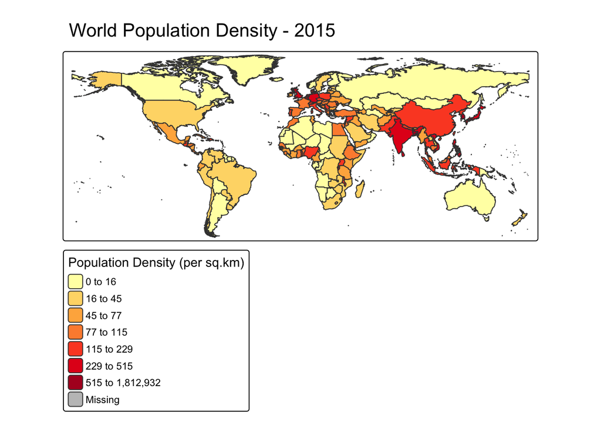

### 2. Make a map of China with Chinese big cities

- make a subset of dataset *Countries* where you choose only one county - China
- use library **library(sf)** to load **cities** file. You can name it *cities*
- in order to choose only Chinese cities you can use **raster library** and “intersect” command. You can also use **st_intersecting** as we did in the tutorials.
- Name the new dataset *Chinese_cities*
- plot a map of China with a background colour of your choice
- plot Chinese cities on the top map of China.You can decide what colour and size the symbols will be. Make sure they are visible on your final map.
- add labels to the cities. Use *CITY_NAME* variable for this purpose.
- add legend and a title to your map

```r
Countries <- st_read("~/Downloads/lab 1_ 2025/Data_assignment/COUNTRIES_ALL.shp")
China<-subset(Countries,Countries$CNTRY_NAME=="China")

cities <- st_read("~/Downloads/lab 1_ 2025/Data_assignment/cities.shp")
```

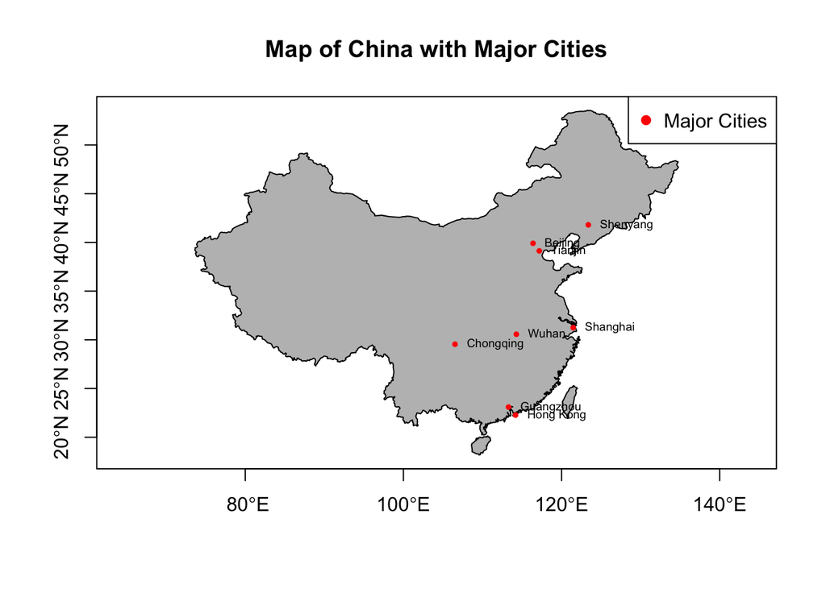

```r
Chinese_cities <- cities[st_intersects(cities, China, sparse = FALSE), ]

plot(st_geometry(China), col = "grey", main = "Map of China with Major Cities", axes = TRUE)
plot(st_geometry(Chinese_cities), add = TRUE, col = "red", pch = 19, cex = 0.5)
text(st_coordinates(Chinese_cities), labels = Chinese_cities$CITY_NAME, cex = 0.6, pos = 4, col = "black")
legend("topright", legend = "Major Cities", pch = 19, cex = 1, col = "red")
```

### 3. Make a map using **“tmap” library**

- make a map of population density of the world with plotted proportional symbols of the world’s cities population from 2015.
- to make this map you can follow the example from the lab
- choose quantile classification and create 6 classes for *POP*
- using tm_bubbles create proportional symbols from a variable *POPULATION* from your *cities* dataset
- add title and legends for both datasets
- make sure your code, comments and the resulting maps are visible in the document.

```r
Countries2 <- subset(Countries, Countries$POP2015 > 0 & Countries$SQKM > 0)
Countries2$POP_DENS <- Countries2$POP2015 / Countries2$SQKM
Countries2 <- Countries2[!is.na(Countries2$POP_DENS) & is.finite(Countries2$POP_DENS), ]
Cities2 <- subset(cities, cities$POPULATION > 0)
breaks <- classIntervals(Countries2$POP_DENS, n = 6, style = "quantile")$brks

Countries2$POP_DENS <- as.numeric(Countries2$POP_DENS)
tm_shape(Countries2) + tm_polygons("POP_DENS", title = "Population Density", palette = "YlOrRd", style = "quantile", n = 6) + tm_shape(Cities2) + tm_bubbles(size = "POPULATION", col = "blue", alpha = 0.5, title.size = "City Population") + tm_layout(title = "World Population Density and City Populations", legend.outside = TRUE)
```

```
## ── tmap v3 code detected ───────────────────────────────────────────────────────
```

[output not shown]

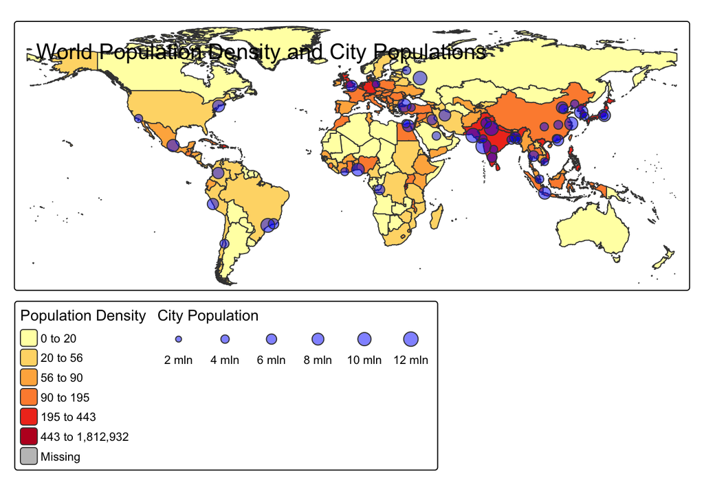

## Instructions for the assignment submission

- Submit one documenet (Rmd knitted as ktml or pdf) with all the responses to tasks from Part 1 and Part 2. Make sure you do it in Rmarkdown.
- Save (knit) your document as a pdf/html and submit via Canvas.
- Part 1 and 2 are equally important. The rubric for this assignmet is available in Modules.